# ggplot2 lab

# Getting Started

Takes data.frame, each line an observation Follows grammar so that we can build upon what we know (instead of list of rules)

1. Data – information we wish to visually represent
2. Aesthetics – map between data and visual properties, i.e., xy axes, color, shape, etc
3. Layer – describe how to render observations

## Data

mpg dataset, see `?mpg`, information on make, model, year, displacement, cylinders, transmission, drive drain, cty and hwy miles, fuel type and car

```r
head(as.data.frame(mpg))
```

```
##   manufacturer model displ year cyl      trans drv cty hwy fl   class
## 1         audi    a4   1.8 1999   4   auto(l5)   f  18  29  p compact
## 2         audi    a4   1.8 1999   4 manual(m5)   f  21  29  p compact
## 3         audi    a4   2.0 2008   4 manual(m6)   f  20  31  p compact
## 4         audi    a4   2.0 2008   4   auto(av)   f  21  30  p compact
## 5         audi    a4   2.8 1999   6   auto(l5)   f  16  26  p compact
## 6         audi    a4   2.8 1999   6 manual(m5)   f  18  26  p compact
```

## Aesthetics

Here, short and sweet, we are going to look at relationship between hwy miles and engine displacement (size)

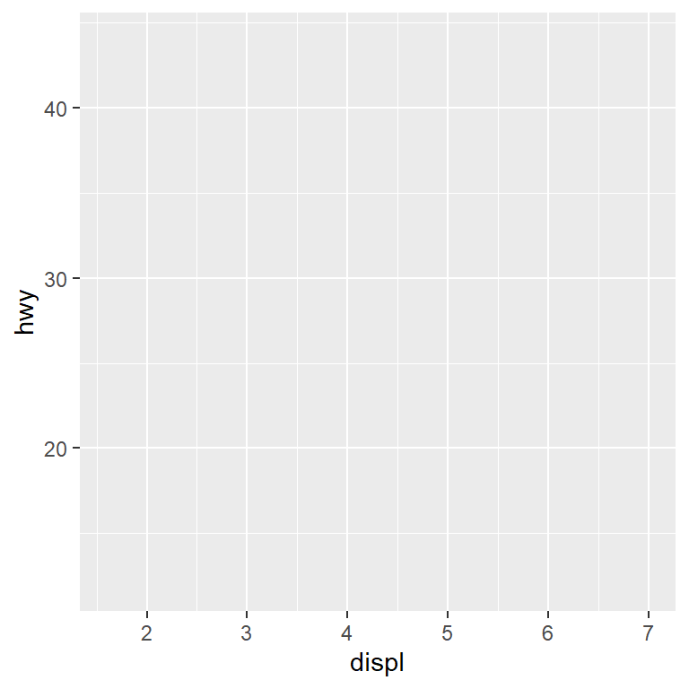

```r
ggplot(data = mpg, aes(x = displ, y = hwy))
```

Here, we have specified data we want (mpg) and have determined axes, but we have not yet specified how we want data rendered

## Layers

accommodates a lot of layers that can be added together, but we start simply. Usually created with a `geom_` function indicating geometry of representation:

- `geom_point` - scatter plots
- `geom_bar` - bar graph for categoricals
- `geom_smooth` - smoother for data
- `geom_boxplot` - box plot
- `geom_histogram` - histograms
- `geom_violin` - violin plot

Relationship between two continuous variables uses scatter plot. When building graphics with ggplot, we use `+` to add to them. Best convention is to end with `+` on each line and then start a new line for every new piece of plot

```r
ggplot(mpg, aes(displ, hwy)) +
  geom_point() # new line, adding points
```

[output not shown]

ggplot allows us to add arbitrary number of layers to plot, allowing us to create precise graphics. Here, we take the scatter plot that we already have an add a data smoother giving us an estimate of best fit

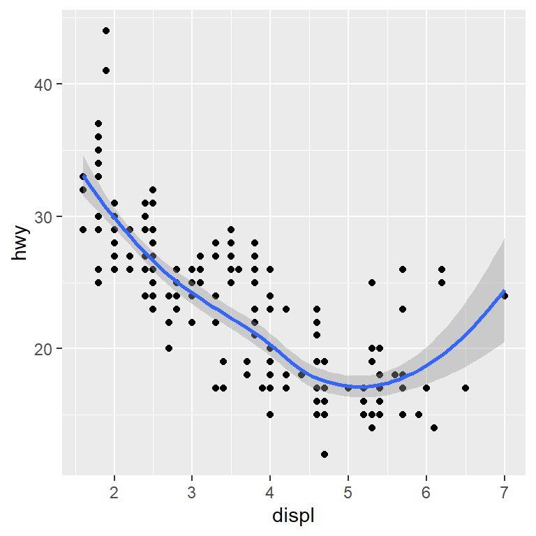

```r
ggplot(mpg, aes(displ, hwy)) +
  geom_point() +
  geom_smooth() # again on a new line
```

The `geom_` functions usually take additional arguments that can modify the output. For example, `geom_smooth` uses a loess curve by default, but if we wished to fit the data to a linear model, we could do so by specifying in an argument

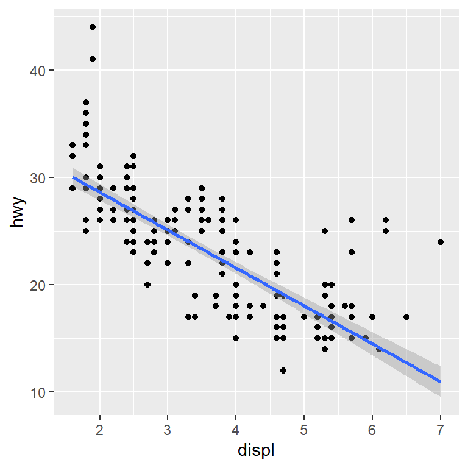

```r
ggplot(mpg, aes(displ, hwy)) +
  geom_point() +
  geom_smooth(method = "lm")
```

```r
# Interesting that bc of color arg smooth does it on groups
# ggplot(mpg, aes(displ, hwy, color = factor(cyl))) +
#   geom_point() +
#   geom_smooth(method = "lm")
```

## Working with groups

Use plotting to identify patterns, helps to briefly compare. Let’s consider relationship between hwy miles and displacement again, yet see if there is any further information associated with the drive train. We can do this in the aes function by setting `color = drv`. Alternatively, `shape = drv`

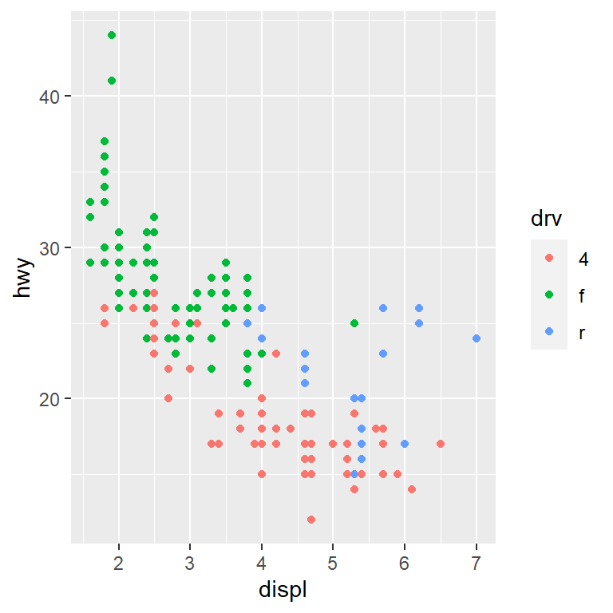

```r
ggplot(mpg, aes(displ, hwy, color = drv)) +
  geom_point()
```

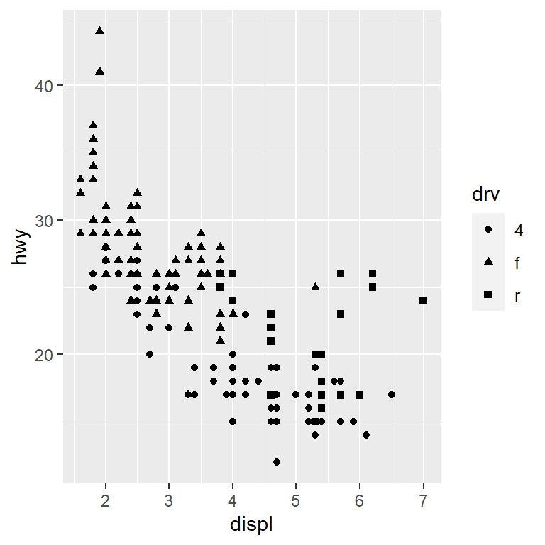

```r
ggplot(mpg, aes(displ, hwy, shape = drv)) +
  geom_point()
```

We can combine aesthetics to compress even more information into the plot, but we must be careful with balance and not overload to make unreadable (art to plotting). Let’s try investigating `class` as well by assigning it to color

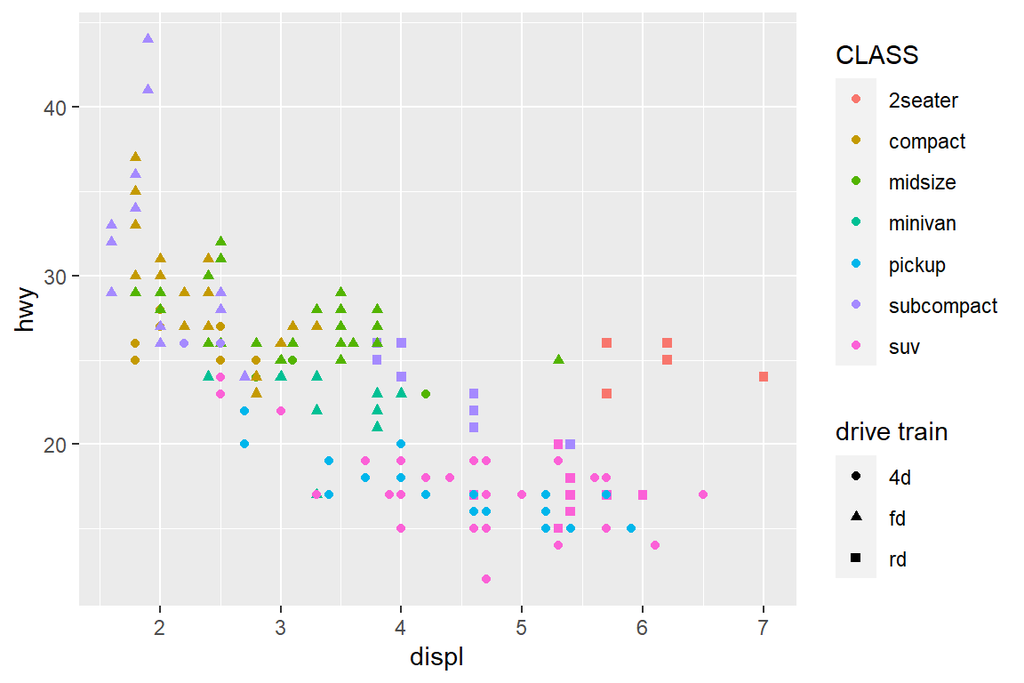

```r
ggplot(mpg, aes(displ, hwy, color = class, shape = drv)) +
  geom_point() +
  labs(color = "CLASS", shape = "drive train") + # fuck this makes too much sense
  scale_shape_discrete(labels = c("4d", "fd", "rd"))
```

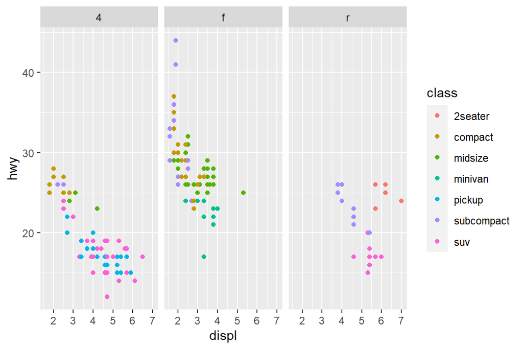

```r
# Maybe here a good time to break this out
ggplot(mpg, aes(displ, hwy, color = class)) +
  geom_point() + facet_wrap(~drv)
```

For this next example, we will consider the distribution of mileage of cars in the dataset. As this is a numeric variable, we can do so with a histogram. We will also specify with an argument to `geom_histogram` how many total bins we want

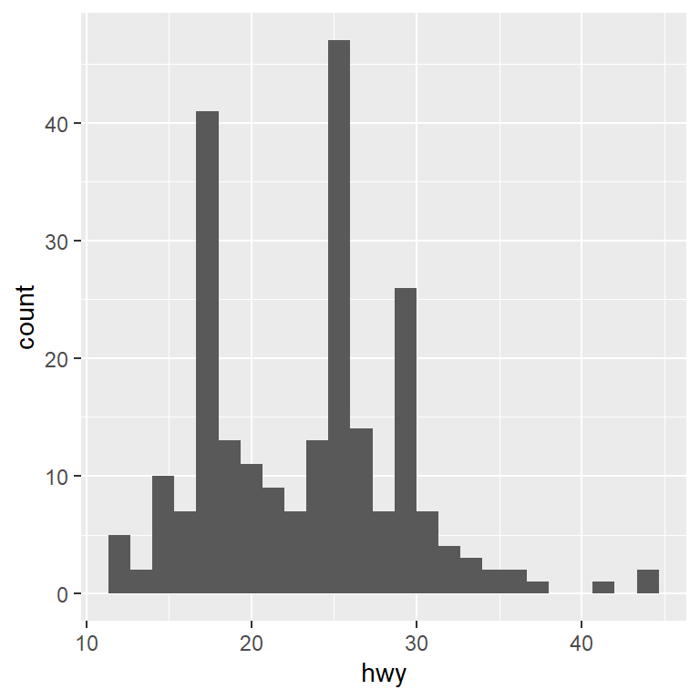

```r
ggplot(mpg, aes(x = hwy)) + # no need to specify a variable for y axis
  geom_histogram(bins = 25)
```

If we wanted to further investigate the relationship between hwy and drive train, we could just add color to the plot, but the nature of histograms makes this unwieldy as the bars will overlap.

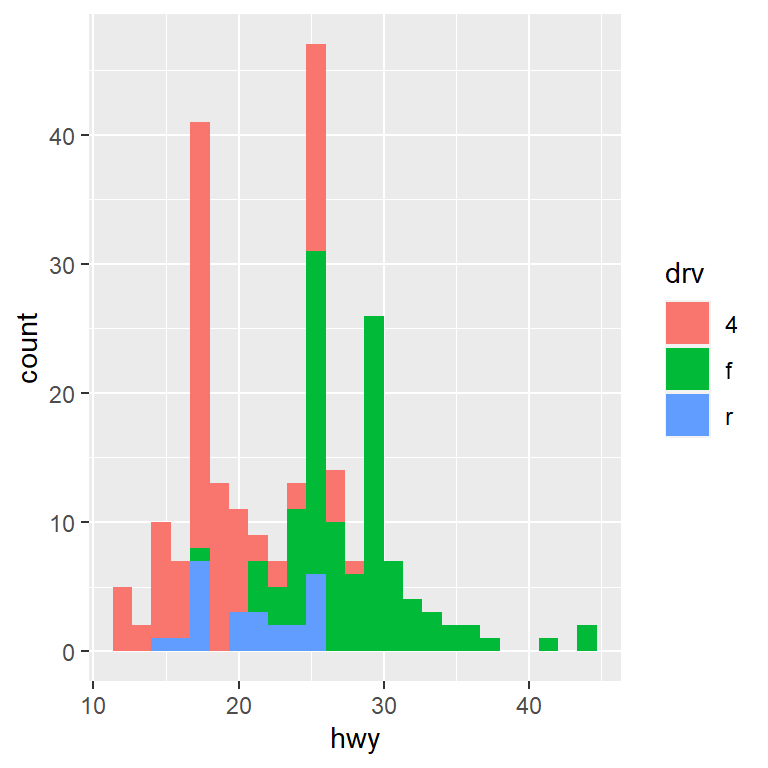

```r
ggplot(mpg, aes(x = hwy, fill = drv)) + # no need to specify a variable for y axis
  geom_histogram(bins = 25)
```

Instead, we can split apart our groups with a technique known as *faceting*. Although not *strictly* necessary, it is most typical to split plots by a character or factor vector rather than a numeric. Here, we plot our histogram again, this time faceting on the `drv` variable. We do this with the `facet_wrap` function, which takes as its argument the variable we wish to facet, along with a tilde, i.e., `~variable`

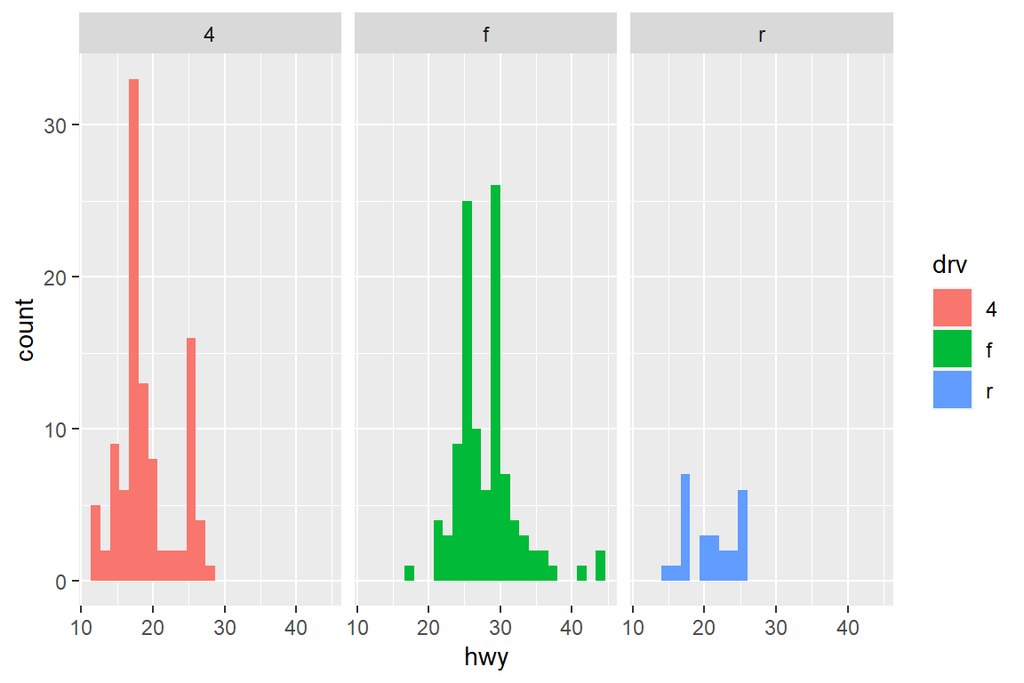

```r
ggplot(mpg, aes(x = hwy, fill = drv)) + # let's keep color variable
  geom_histogram(bins = 25) +
  facet_wrap(~drv) # note that it is ~drv
```

## Bar Charts

A note on bar charts

```r
x <- sample(letters[1:5], size = 30, replace = TRUE)

xtab <- as.data.frame(table(x))
xdf <- as.data.frame(x)

# xdf is a data.frame with one column
xdf
```

```
##    x
## 1  b
## 2  d
## 3  e
## 4  d
## 5  e
## 6  e
## 7  d
## 8  b
## 9  b
## 10 e
## 11 d
## 12 e
## 13 c
## 14 d
```

[output cut: 16 more lines]

```r
# xtab is a data.frame with two columns
xtab
```

```
##   x Freq
## 1 a    5
## 2 b    3
## 3 c    6
## 4 d   10
## 5 e    6
```

General rule that each row is an observation. So if we are looking at letters collected, see that we have 30. That makes us think 30 rows, which is what we see for xdf, this works fine.

However, sometimes your row is not an individual observation, but a summary of observations. See that `xtab` has each row indicate how frequently each letter showed up. Now we have an x and y variable, but if we try to do this we get an error. We can do this by changing the `stat` argument to be identity (instead of default of counting)

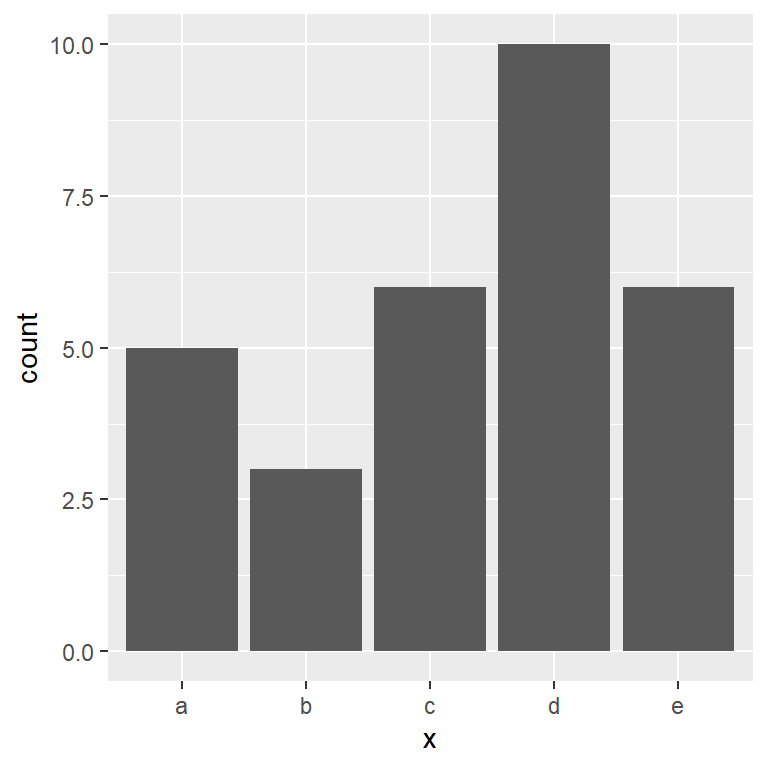

```r
ggplot(xdf, aes(x)) + geom_bar()
```

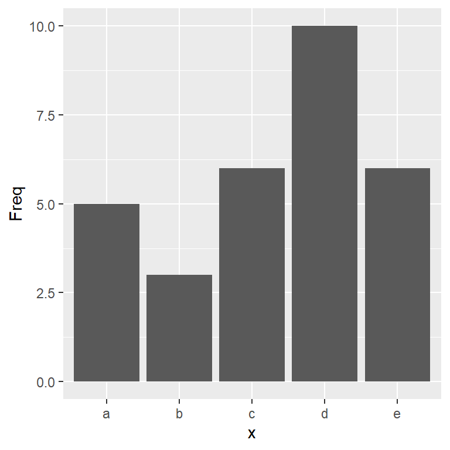

```r
#ggplot(xtab, aes(x, Freq)) + geom_bar() # error
ggplot(xtab, aes(x, Freq)) + geom_bar(stat = "identity")
```

## Extra

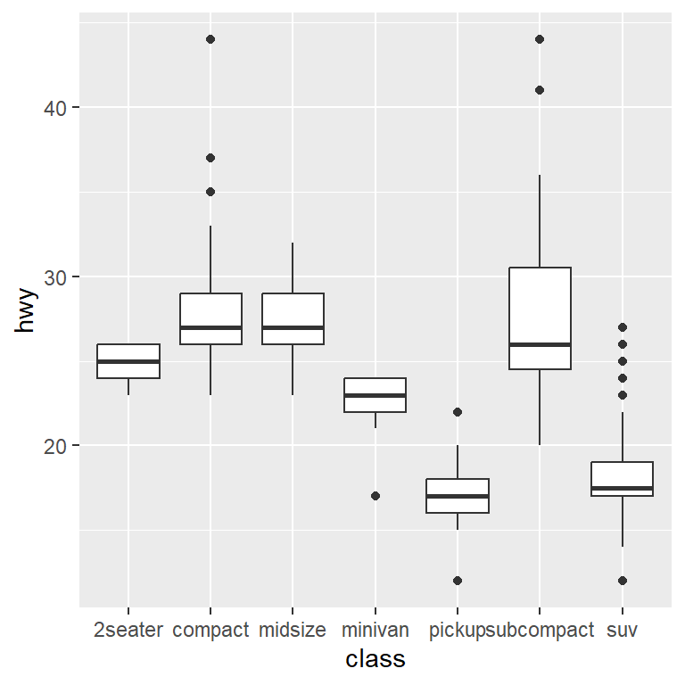

```r
ggplot(mpg, aes(class, hwy)) + geom_boxplot()
```

## Theme

legend, color

## Adding complexity

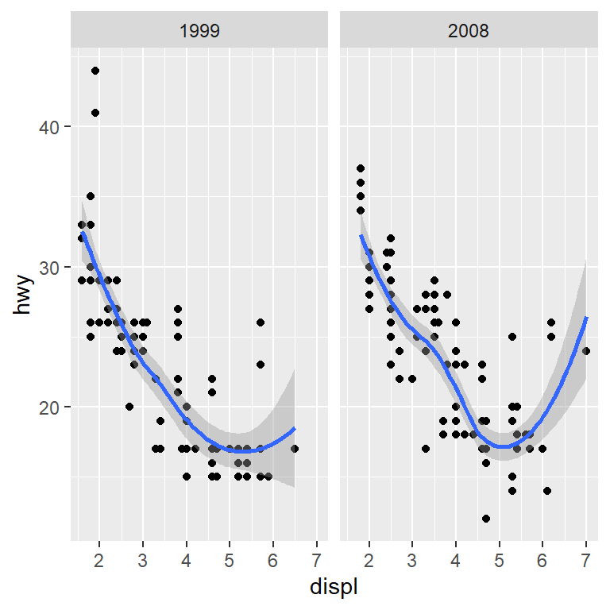

```r
# would be good to have them make this one
ggplot(mpg, aes(displ, hwy)) +
  geom_point() +
  geom_smooth() +
  facet_wrap(~year)
```

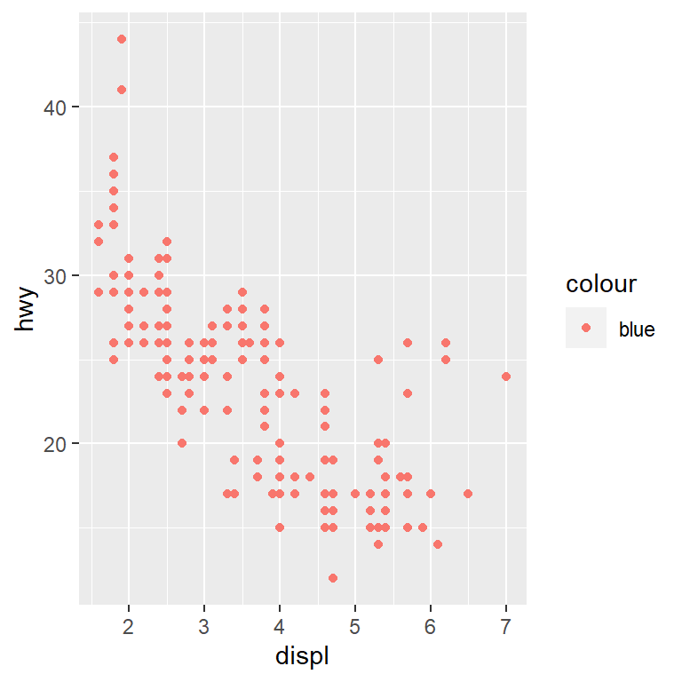

```r
ggplot(mpg, aes(displ, hwy)) +
  geom_point(aes(color = "blue"))
```

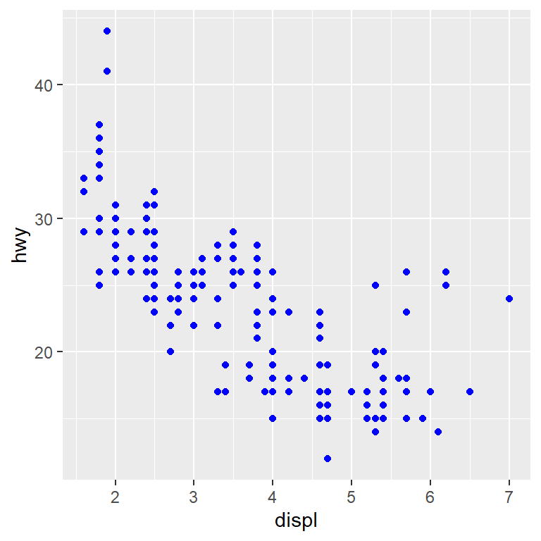

```r
ggplot(mpg, aes(displ, hwy)) +
  geom_point(aes(color = I("blue"))) # but no legend here, why?
```

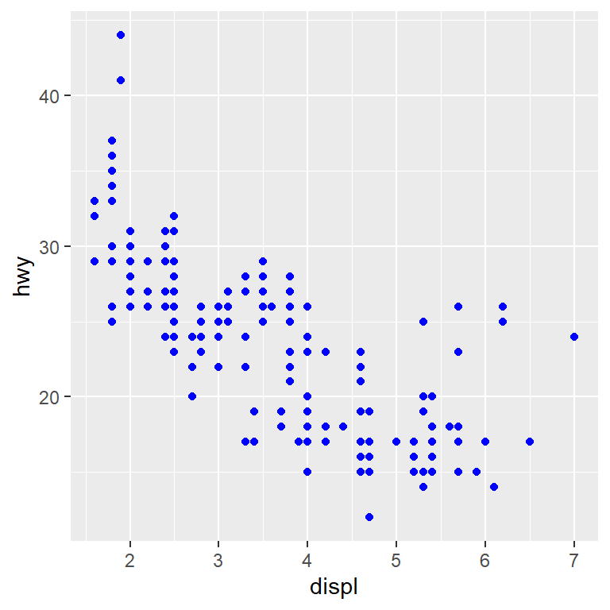

```r
# What is happening here?
ggplot(mpg, aes(displ, hwy)) +
  geom_point(color = "blue") # set to fixed attribute
```

Setting aesthetics in plots vs layers (wow this makes a lot of sense)

```r
# pg 95-96
```

```r
library(dplyr)
```

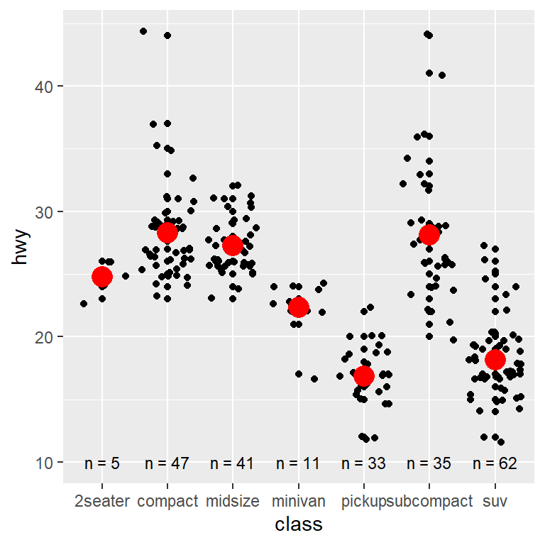

```r
library(magrittr)
class <- mpg %>% group_by(class) %>% summarize(n = n(), hwy = mean(hwy))


ggplot(mpg, aes(x = class, y = hwy)) +
  geom_point() + geom_jitter() +
  geom_point(data = class, color = 'red', size = 5) +
  geom_text(data = class, aes(y = 10, label = paste0("n = ", n)), size = 3)
```

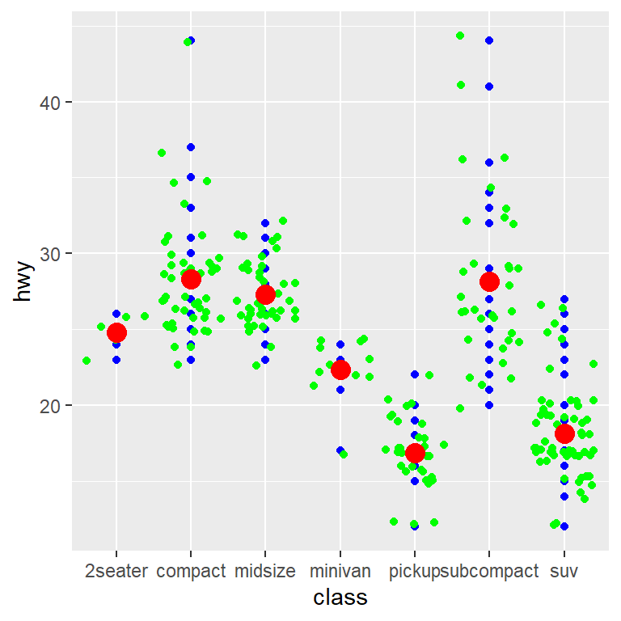

```r
ggplot(mpg, aes(class, hwy)) +
  geom_point(color = "blue", show.legend = TRUE) + geom_jitter(color = "green", show.legend = TRUE) +
  stat_summary(geom = "point", fun = "mean", color = 'red', size = 4)
```

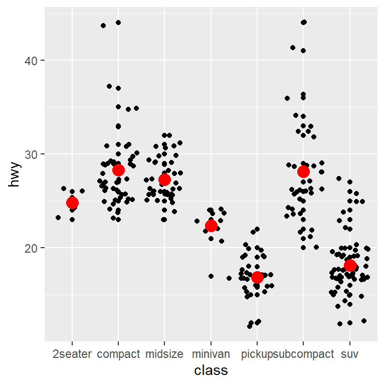

```r
ggplot(mpg, aes(class, hwy)) +
  geom_point() + geom_jitter() +
  stat_summary(geom = "point", fun = "mean", aes(color = I('red')), size = 4)
```

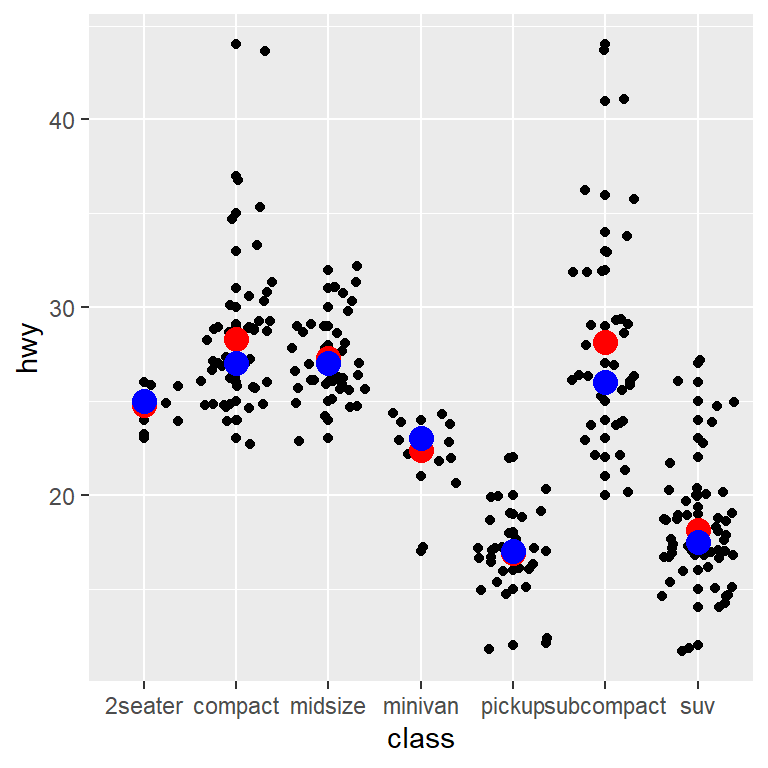

```r
ggplot(mpg, aes(class, hwy)) +
  geom_point() + geom_jitter() +
  geom_point(stat = "summary", fun = "mean", aes(color = I('red')), size = 4) +
  geom_point(stat = "summary", fun = "median", aes(color = I('blue')), size = 4)
```

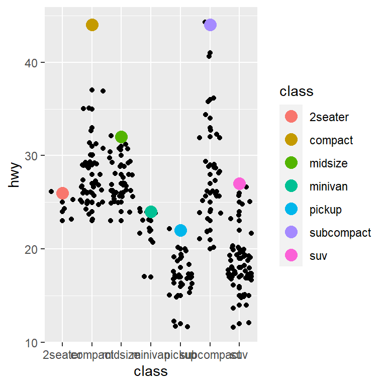

```r
ggplot(mpg, aes(class, hwy)) +
  geom_point() + geom_jitter() +
  stat_summary(geom = "point", fun = "max", aes(color = class), size = 4)
```

more on stat summary for other geom

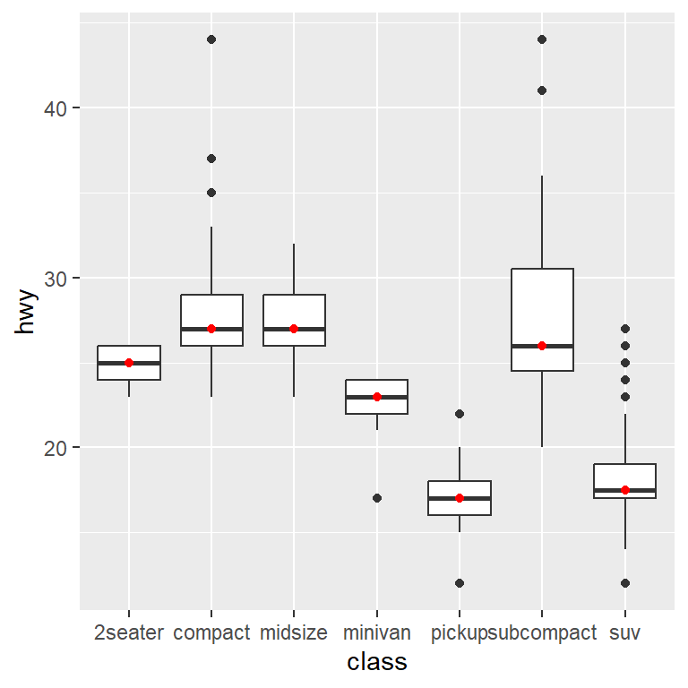

```r
ggplot(mpg, aes(class, hwy)) +
  geom_boxplot() +
  stat_summary(geom = "point", fun = "median", color = 'red')
```

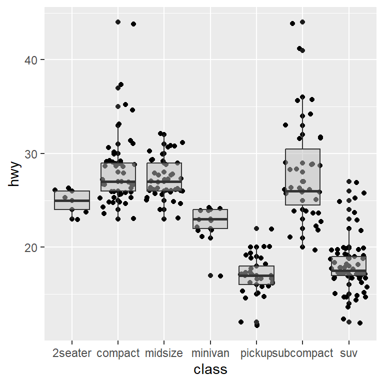

```r
## Something like this would be a good one to make/reproduce
ggplot(mpg, aes(class, hwy)) +
  geom_point() + geom_jitter() +
  geom_boxplot(alpha = 0.5, fill = 'gray')
```

```r
  stat_summary(geom = "boxplot", color = 'red')
```

```
## geom_boxplot: na.rm = FALSE, orientation = NA
## stat_summary: fun.data = NULL, fun = NULL, fun.max = NULL, fun.min = NULL, fun.args = list(), na.rm = FALSE, orientation = NA
## position_identity
```

## Scales

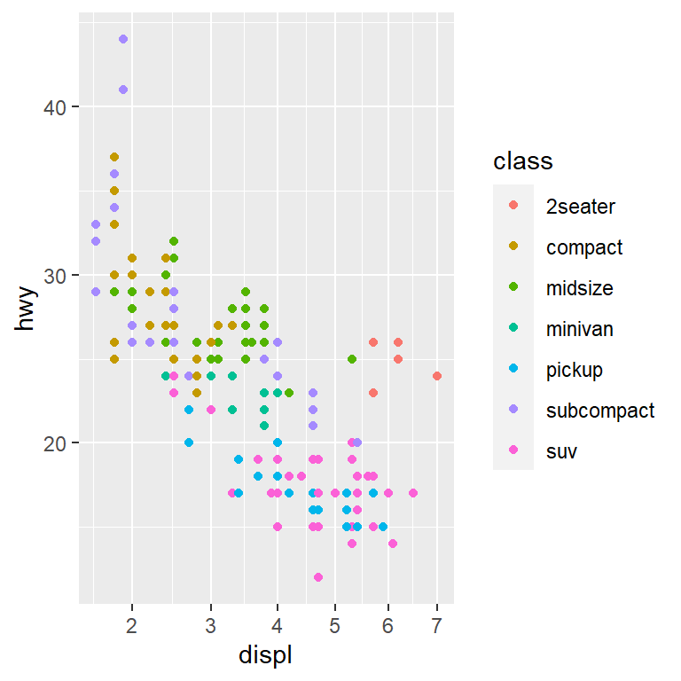

```r
ggplot(mpg, aes(displ, hwy)) +
  geom_point(aes(color = class)) + scale_x_sqrt() +
  scale_color_discrete()
```

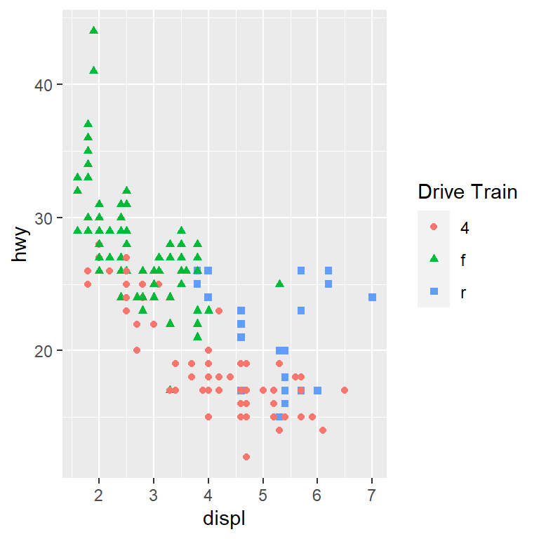

```r
# pg 125
ggplot(mpg, aes(displ, hwy)) +
  geom_point(aes(color = drv, shape = drv)) +
  scale_color_discrete("Drive Train") +
  scale_shape_discrete("Drive Train")
```

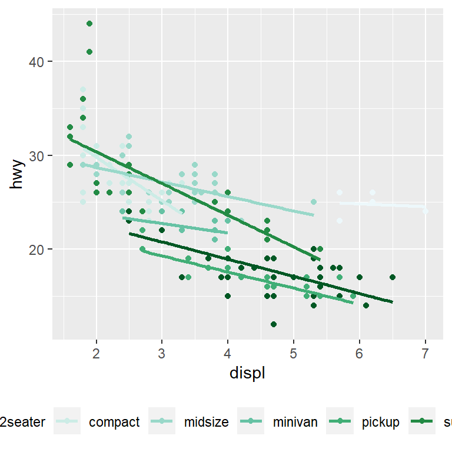

```r
# pg 126
ggplot(mpg, aes(displ, hwy, color = class)) +
  geom_point() +
  geom_smooth(method = "lm", se = FALSE) +
  theme(legend.position = "bottom") +
  guides(color = guide_legend(nrow = 1)) +
  scale_color_brewer(palette = 2) +
  scale_x_continuous(limits = c(NA, NA))
```

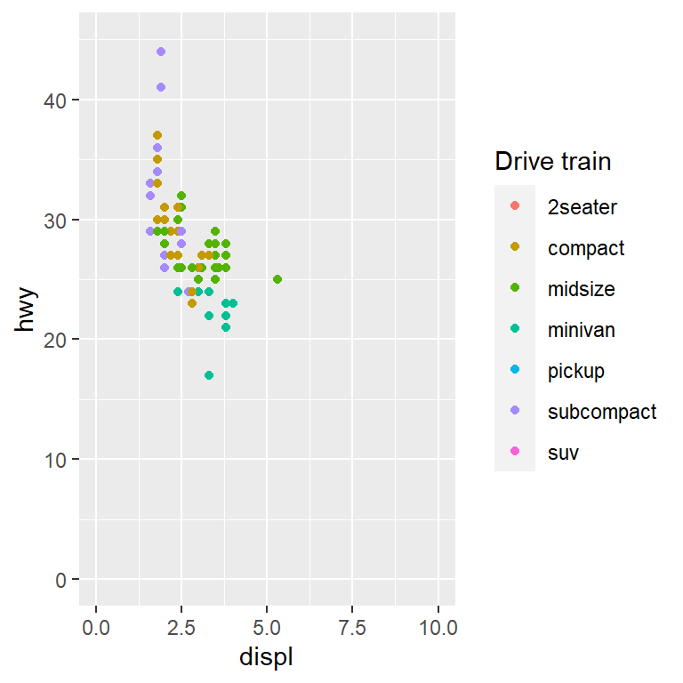

```r
fwd <- subset(mpg, drv == "f")
rwd <- subset(mpg, drv == "r")
ggplot(fwd, aes(displ, hwy, colour = class)) +
  geom_point() +
  scale_color_discrete("Drive train") +
  xlim(0, 10) +
  ylim(0, 45) +
  expand_limits(color = c("2seater", "compact", "midsize", "minivan",
                                   "pickup", "subcompact", "suv"))
```

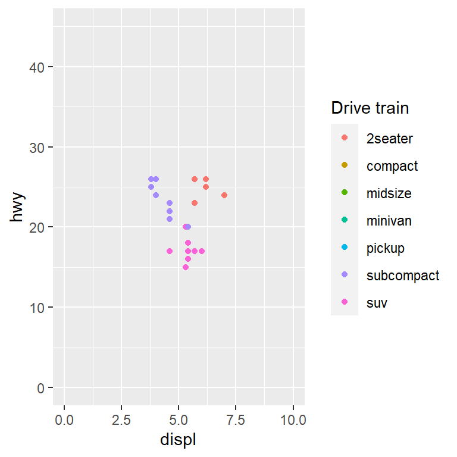

```r
ggplot(rwd, aes(displ, hwy, colour = class)) +
  geom_point() +
  scale_color_discrete("Drive train") +
  xlim(0, 10) +
  ylim(0, 45) +
  expand_limits(color = c("2seater", "compact", "midsize", "minivan",
                                   "pickup", "subcompact", "suv"))
```

```r
# Why are these the same?
ggplot(mpg, aes(displ, hwy)) +
  geom_point()
```

[output not shown]

```r
ggplot(mpg) +
  geom_point(aes(displ, hwy))
```

[output not shown]

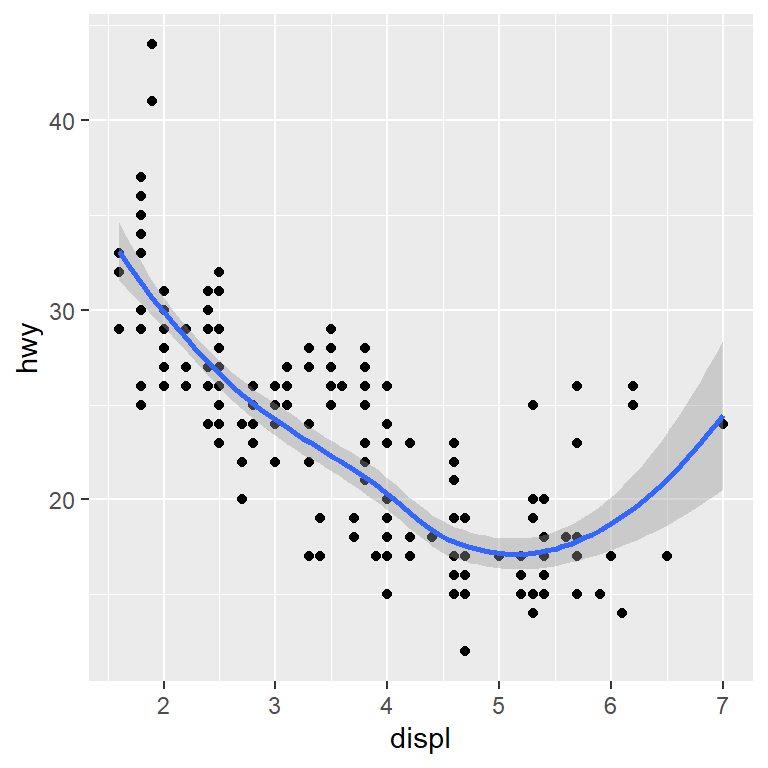

```r
# Why does one of these work and not the other?
ggplot(mpg, aes(displ, hwy)) +
  geom_point() + geom_smooth()
```

```r
# does not work
# ggplot(mpg) +
#   geom_point(aes(displ, hwy)) +
#   geom_smooth()
```

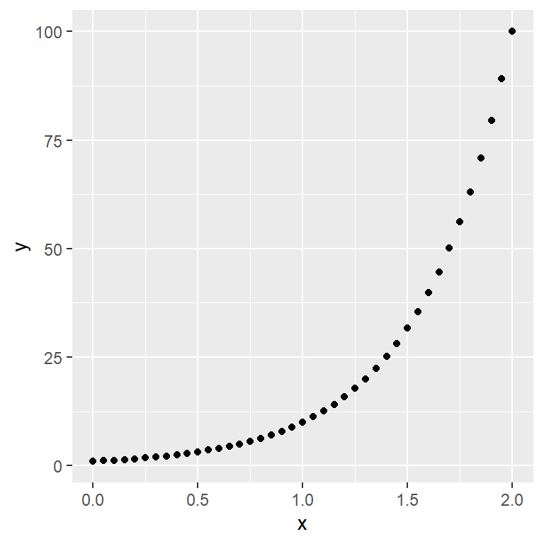

```r
dfe <- data.frame(x = seq(0, 2, by = 0.05),
                  y = 10^(seq(0, 2, by = 0.05)))


## Scale functions
ggplot(dfe, aes(x, y)) +
  geom_point()
```

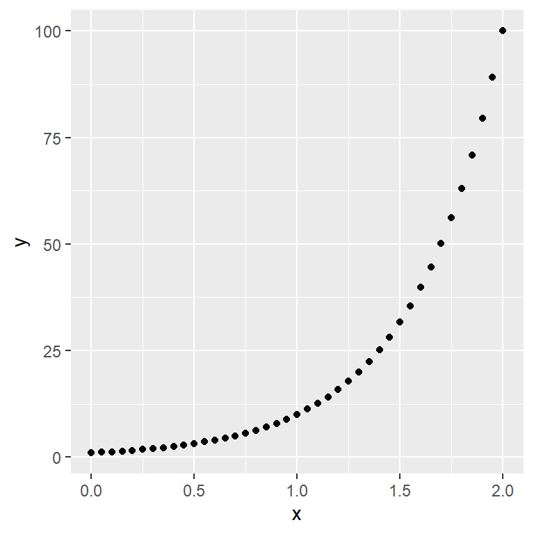

```r
# exact same as
ggplot(dfe, aes(x, y)) +
  geom_point() +
  scale_y_continuous() # this happens by default
```

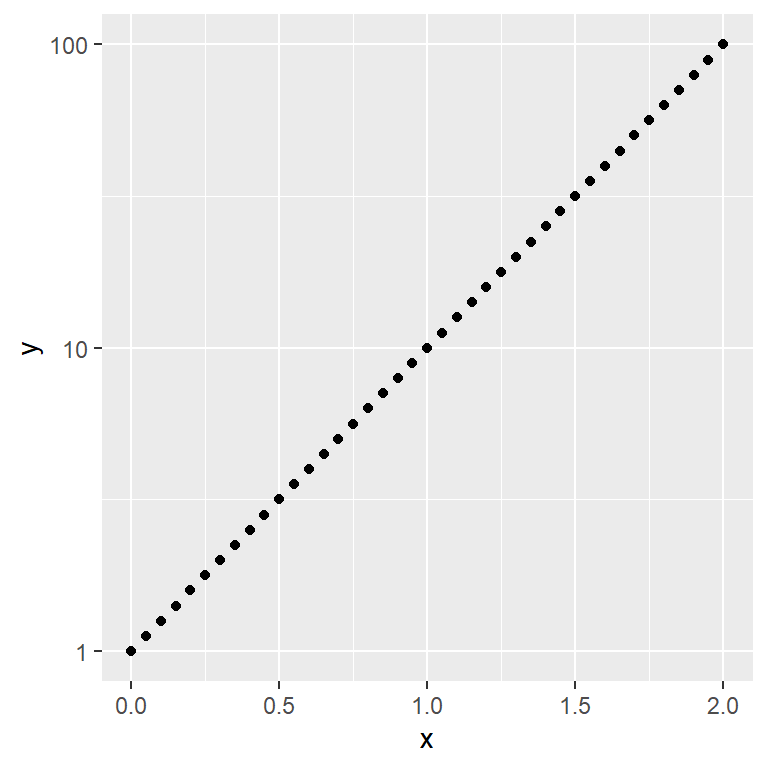

```r
ggplot(dfe, aes(x, y)) +
  geom_point() +
  scale_y_continuous(trans = "log10") # identity, log, exp, logit, sqrt, etc
```

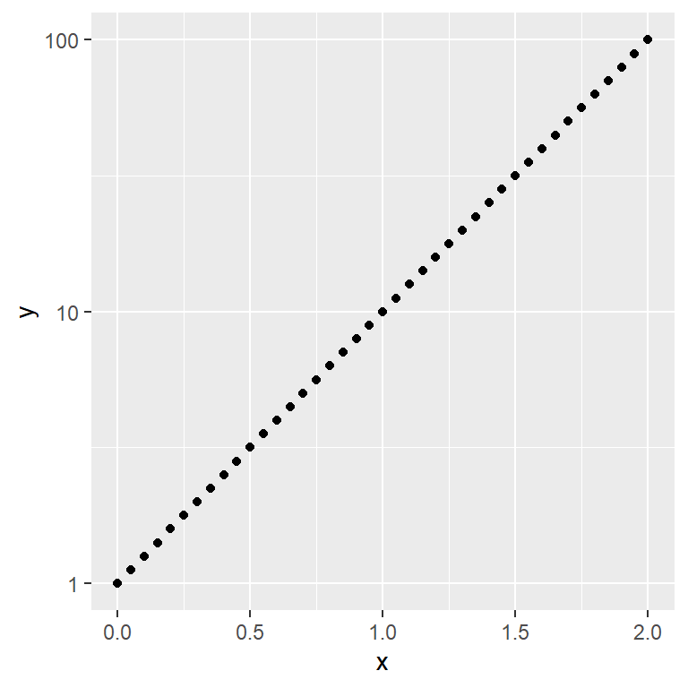

```r
# for some its built in
ggplot(dfe, aes(x, y)) +
  geom_point() +
  scale_y_log10()
```

```r
url <- "https://collinn.github.io/juice.png"
```

[figure not shown]

another stat summary

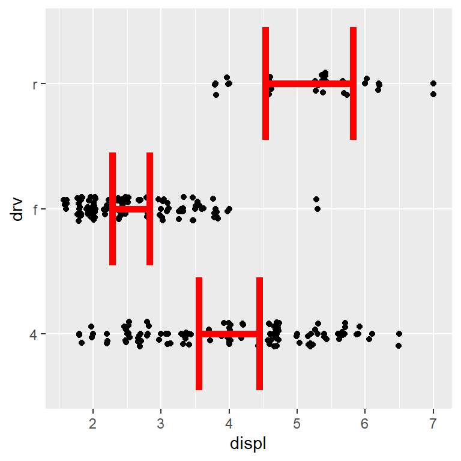

```r
ggplot(mpg, aes(displ, drv)) +
  geom_point() + geom_jitter(height = 0.1) +
  stat_summary(fun.data = mean_se, geom = "errorbar", color = 'red', fun.args = c(mult = 4), linewidth = 2)
```

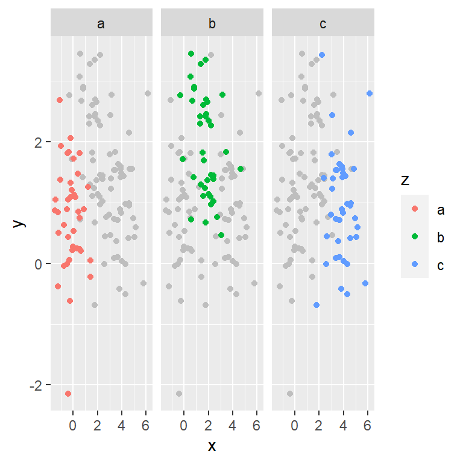

```r
df <- data.frame(x = rnorm(120, c(0, 2, 4)),
                 y = rnorm(120, c(1,2,1)),
                 z = letters[1:3])

df2 <- df[, c("x", "y")]

ggplot(df, aes(x, y)) +
  geom_point(data = df2, color = "gray") +
  geom_point(aes(color = z)) +
  facet_wrap(~z)
```